# FFT-lecture slides

## The Fast Fourier Transform (FFT)

Here we'll walk through how to use the Python/Numpy FFT interface.

```python
import numpy as np
from numpy import fft # the "fft" module namespace
```

```python
# https://numpy.org/doc/stable/reference/routines.fft.html
help(fft)
```

[output not shown]

[output cut: 1456 more lines]

[output not shown]

Define and evaluate our function

```python
@np.vectorize
def boxcar(x):
    if np.abs(x) < 0.5:
        return 1.0
    elif np.abs(x) == 0.5:
        return 0.5
    else:
        return 0.0

xs = np.linspace(-2, 2, 64)
ys = boxcar(xs)
```

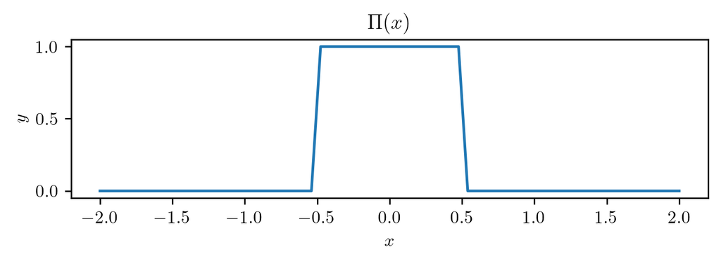

```python
plt.plot(xs, ys)
plt.xlabel(r"$x$")
plt.ylabel(r"$y$")
plt.gca().set_aspect('equal')
plt.title(r"$\Pi(x)$");
```

What do we expect the Fourier transform to be?

Remember, we are *actually* dealing with discrete samples

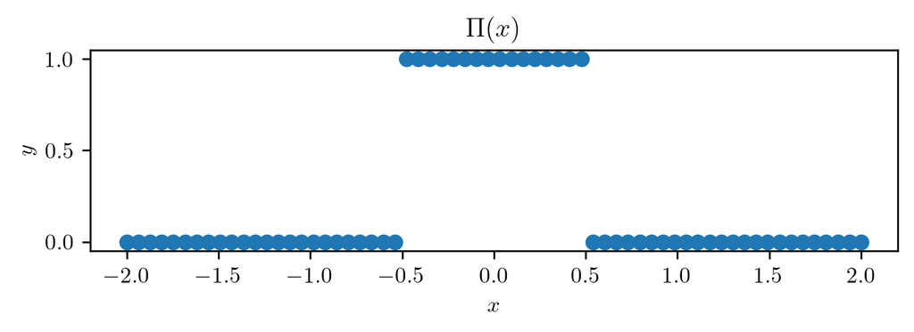

```python
plt.plot(xs, ys, "o")
plt.xlabel(r"$x$")
plt.ylabel(r"$y$")
plt.title(r"$\Pi(x)$");
plt.gca().set_aspect('equal')
```

**FFTs work on arrays of data**

```python
Ys = fft.fft(ys) # note, no xs array required
```

```python
print(Ys[:10])
```

```
[ 16.        +0.j         -14.39348919-0.70710678j
  10.15317039+1.j          -4.76692671-0.70710678j
   0.        +0.j           2.82292851+0.70710678j
  -3.29655821-1.j           1.97623106+0.70710678j
   0.        +0.j          -1.49505168-0.70710678j]
```

- The output is complex (in general)
- No units anywhere
- We have non-zero imaginary values --- is this right for a boxcar?

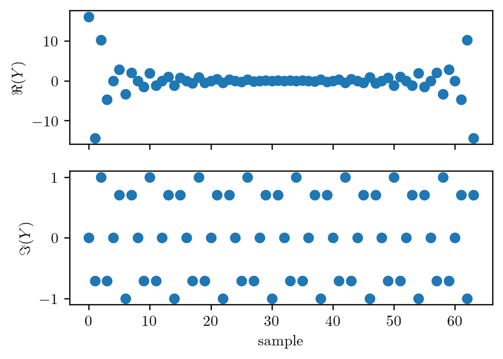

```python
fig, ax = plt.subplots(nrows=2, sharex=True, figsize=(5,3.5))
ax[0].plot(np.real(Ys), "o")
ax[0].set_ylabel(r"$\Re(Y)$")
ax[1].plot(np.imag(Ys), "o")
ax[1].set_ylabel(r"$\Im(Y)$");
ax[1].set_xlabel("sample");
```

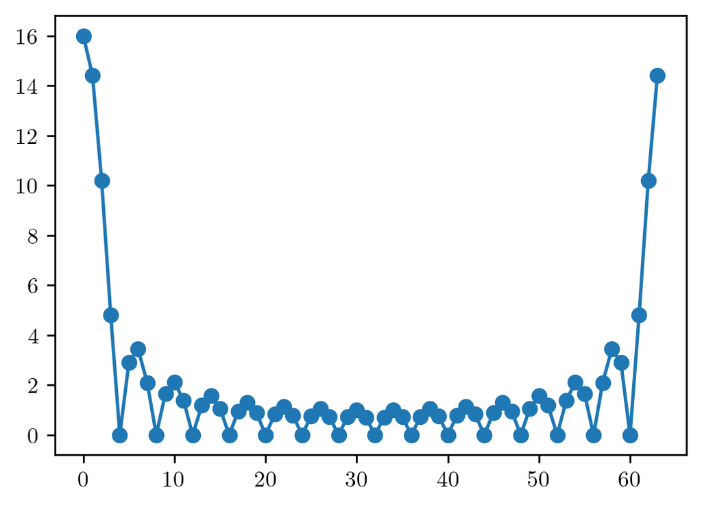

```python
fig, ax = plt.subplots(nrows=1, figsize=(5,3.5))
ax.plot(np.abs(Ys), "C0")
ax.plot(np.abs(Ys), "o", color="C0")
```

This looks like a $|\mathrm{sinc}|$ function, but something is still off.

We can see the problem another way by plotting amplitude and phase

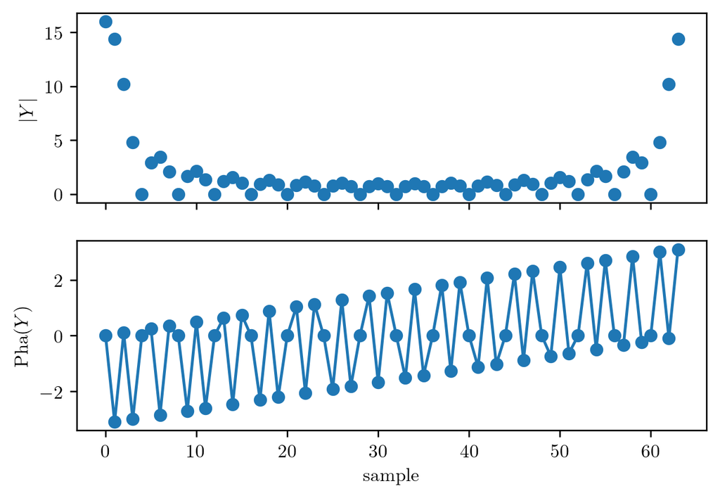

```python
fig, ax = plt.subplots(nrows=2, sharex=True, figsize=(6,4))
ax[0].plot(np.abs(Ys), "o")
ax[0].set_ylabel(r"$|Y|$")
ax[1].plot(np.angle(Ys), color="C0")
ax[1].plot(np.angle(Ys), "o", color="C0")
ax[1].set_ylabel(r"$\mathrm{Pha}(Y)$");
ax[1].set_xlabel("sample");
```

What's going on here? Let's revisit the DFT of a set of $N$ samples $$ F_k = \sum_{m=0}^{N-1} f_m \exp \left ( - 2 \pi i \frac{m k}{N} \right) $$

- input samples: index $m$
- output samples: index $k$
- output frequency: $k/N$ in units of "cycles per sampling interval"

**Packing the input** In the exponent, $m$ serves as an x-coordinate. The routine expects $f_0 = f(x = 0)$. But we effectively fed it $f_0 = f(x = -2)$ by mistake. The solution is to "pack" the input array using `np.fft.fftshift`.

**Unpacking the output** Nyquist Shannon limit is satisfied with at least 2 samples/cycle, equivalent to a cutoff frequency of 0.5 cycles per sampling interval (maximum frequency $k = N/2$). So what do values $k > N/2$ correspond to? Negative frequencies.

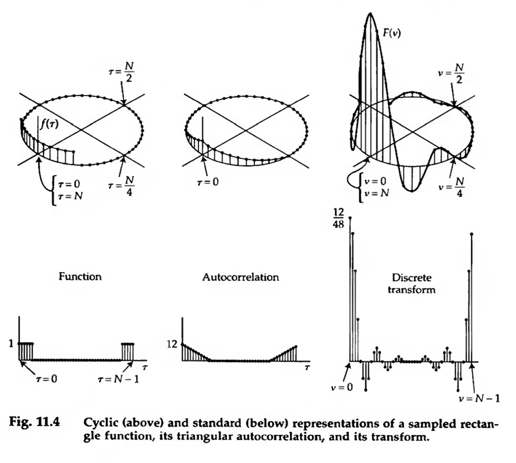

```python
from IPython.display import Image
Image(filename='DFT-cyclical.png')
```

## Fixing our mistakes

If you want to use the DFT/FFT as a full numerical replacement,

1. Make sure $m=0$ sample corresponds to $x=0$ starting point (`fftshift`)
2. Scale FFT output by appropriate $\Delta$ spacing of input
3. Unshift frequency components (`fftshift` again)
4. Calculate frequency output values by converting from "cycles per sampling interval" or just use `fftfreqs`

To sample the input, I normally use `np.arange` instead of linspace

```python
Delta_x = 0.1 # meter
N = 40
xs = Delta_x * np.arange(-N/2, N/2)
print(xs)
```

```
[-2.  -1.9 -1.8 -1.7 -1.6 -1.5 -1.4 -1.3 -1.2 -1.1 -1.  -0.9 -0.8 -0.7
 -0.6 -0.5 -0.4 -0.3 -0.2 -0.1  0.   0.1  0.2  0.3  0.4  0.5  0.6  0.7
  0.8  0.9  1.   1.1  1.2  1.3  1.4  1.5  1.6  1.7  1.8  1.9]
```

```python
ys = boxcar(xs)
print(ys)
```

```
[0.  0.  0.  0.  0.  0.  0.  0.  0.  0.  0.  0.  0.  0.  0.  0.5 1.  1.
 1.  1.  1.  1.  1.  1.  1.  0.5 0.  0.  0.  0.  0.  0.  0.  0.  0.  0.
 0.  0.  0.  0. ]
```

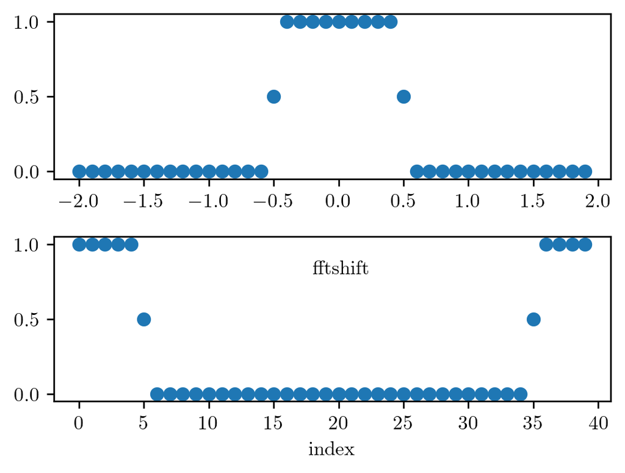

```python
fig, ax = plt.subplots(nrows=2, figsize=(5,3.5))
ax[0].plot(xs, ys, "o")
ax[1].plot(fft.fftshift(ys), "o")
ax[1].text(18, 0.8, "fftshift")
ax[1].set_xlabel("index")
fig.subplots_adjust(hspace=0.35)
```

Finally, to use the DFT as an approximation of the Fourier transform of a function and get the correct normalization factor, we need to approximate the integral as a discrete sum $$ F(s) = \int_{-\infty}^{\infty} f(x) \exp \left (- 2 \pi i x s \right)\,\mathrm{d}x \approx \sum_{m = 0}^{N-1} f_m \exp \left ( - 2 \pi i \frac{m k}{N} \right) \Delta $$ where $\Delta$ is the spacing between input samples.

```python
output = fft.fft(fft.fftshift(ys))
scaled_output = Delta_x * output
```

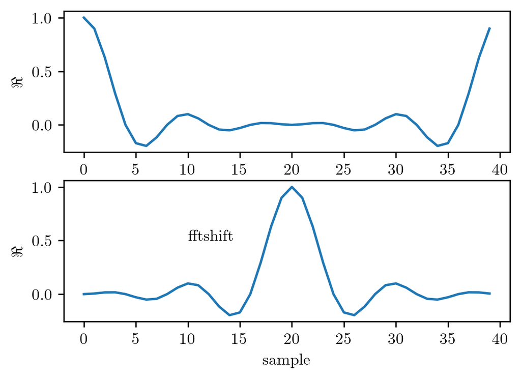

```python
fig, ax = plt.subplots(nrows=2, figsize=(5, 3.5))
ax[0].plot(np.real(scaled_output))
ax[0].set_ylabel(r"$\Re$")
ax[1].plot(np.real(np.fft.fftshift(scaled_output)))
ax[1].set_ylabel(r"$\Re$")
ax[1].set_xlabel("sample")
ax[1].text(10, 0.50, "fftshift");
```

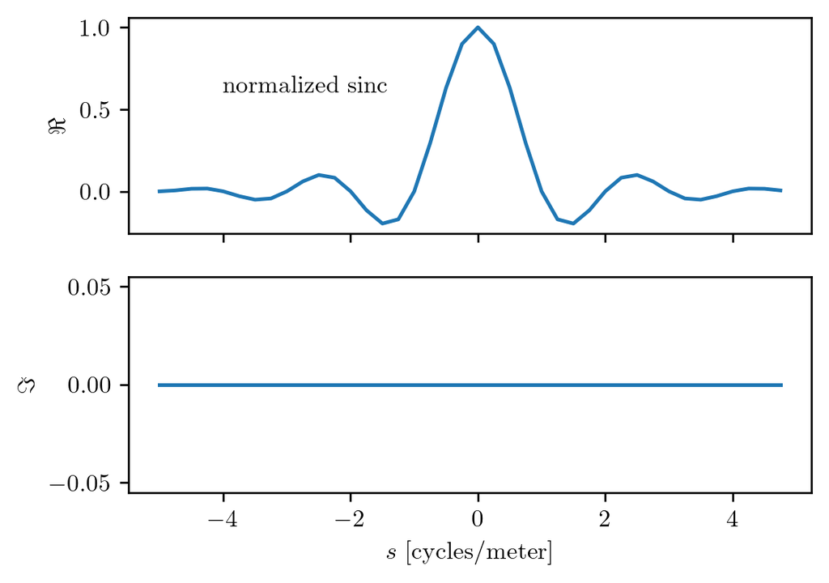

```python
s = fft.fftfreq(N, d=Delta_x) # designed to be used with non-FFT shifted output!
shifted_s = fft.fftshift(s)

fig, ax = plt.subplots(nrows=2, sharex=True, figsize=(5,3.5))
ax[0].plot(shifted_s, np.real(np.fft.fftshift(scaled_output)))
ax[0].set_ylabel(r"$\Re$")
ax[1].plot(shifted_s, np.imag(np.fft.fftshift(scaled_output)))
ax[1].set_ylabel(r"$\Im$")
ax[1].set_xlabel(r"$s$ [cycles/meter]");
ax[0].text(-4, 0.6, "normalized sinc");
```

## Fixing our mistakes

If you want to use the DFT/FFT as a full numerical replacement,

1. Make sure $m=0$ sample corresponds to $x=0$ starting point (`fftshift`)
2. Scale FFT output by appropriate $\Delta$ spacing of input
3. Unshift frequency components (`fftshift` again)
4. Calculate frequency output values by converting from "cycles per sampling interval" or just use `fftfreqs`

[Musical Spectrogram link](https://musiclab.chromeexperiments.com/spectrogram/)